# Appendix

Elie

5/28/2021

# 1. Drifting resource

The drifting resource function has the following properties

1. The total amount of resource across space is constant throughout the year.
2. At the beginning, middle, and end of the year the resource is uniformly distributed.
3. At some peak time $\mu_t < \tau/2$, the resource concentrates at a location $\mu_x < \chi$ with a spatial deviation $\sigma_x$ and a temporal deviation $\sigma_t$ (where $\tau$ is the length of the year and $\chi$ is the extent of the spatial domain).
4. The resource peaks exactly symmetrically at time $\tau - \mu_t$ and location $-\mu_x$ with the same variances.

To generate a resource with these properties, we distributing the resource in space as a beta distribution, where the two shape and scale parameters vary sinusoidally in such a way as to fulfill the criteria above. Thus:

$$h(x,t, \theta) = \chi B(x/\chi, a(t, \theta), b(t, \theta))$$

where $\chi$ is the maximum value (domain) of $x$, $B(x, a, b)$ is the beta distribution, $\theta$ represents the set of parameters $t_r, x_r, \sigma_t, \sigma_x$, and the two shape parameters are given by:

$$a(t) = \frac{m}{s^2}( s^2 + m - m^2)$$
$$b(t, x', \sigma') = (m-1)\left(1 + \frac{m}{s}(m-1)\right)$$

where $m(t)$ and $s(t)$ describe the dynamic mean and variance of the resource peak. These equations are solutions to the mean and variance of the beta distribution, $\mu = \alpha/(\alpha + \beta)$, $\sigma^2 = \frac{\alpha\beta}{(\alpha+\beta)^2(\alpha+\beta+1)}$.

The means and variances themselves are Gaussian pulses, with the mean peaking at $\mu_x$ at time $\mu_t$ with standard deviation $\sigma_t$ and at $-\mu_x$ at time $\tau - \mu_t$ and the standard deviation pulsing from $2 \chi/\sqrt{12}$ (corresponding to a uniform distribution over the domain $-\chi$ to $\chi$) at times 0, $\tau/2$ and $\tau$ down to $\sigma_x$ at $t_r$ and $\tau - t_r$, with standard deviation (in time) $\sigma_t$.

Examples of the drifting resource are below.

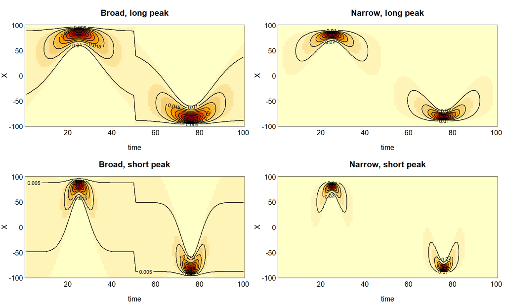